# exploratory

Ehsan

10/27/2021

```r
library(ggplot2)
library(tidyverse)
library("readxl")
library(dplyr)
library(here)
```

#Read data

```r
data_location <- here::here("data","processed_data","processeddata.rds")
data1 <- readRDS(data_location)
```

#Summary for the main outcome variable

```r
summary(data1$infection_status_info)
```

```
##   noTest negative positive
##      445      197       64
```

#check if this column is a factor or not

```r
is.factor(data1$infection_status_info)
```

```
## [1] TRUE
```

#plotting infection_status_info count and save the result

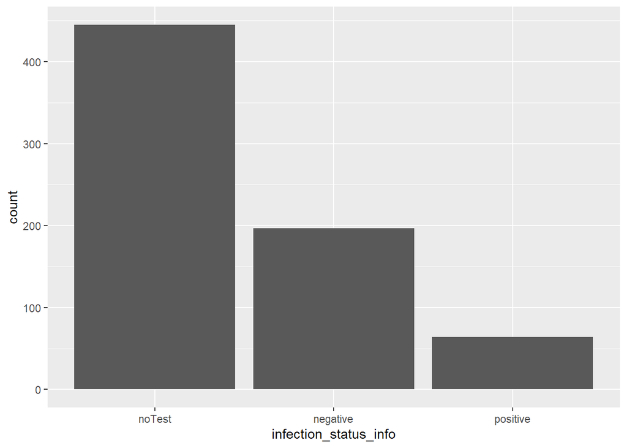

```r
plot1 <- ggplot(data = data1) +
    geom_bar(mapping = aes(x = infection_status_info))
plot1
```

```r
figure_file = here("results","infection_status_info_distribution.png")
ggsave(filename = figure_file, plot=plot1)
```

#I want to see how many NA values are there for each column. So, I wrote the following code. For manuscript we dont need it.

```r
cbind(
      lapply(
             lapply(data1, is.na)
             , sum)
  )
```

```
##                                                                                                                                                                                                          [,1]
## serial                                                                                                                                                                                                   0
## Created                                                                                                                                                                                                  0
## Age                                                                                                                                                                                                      0
## Sex                                                                                                                                                                                                      0
## Country of residence:                                                                                                                                                                                    0
## education                                                                                                                                                                                                0
## student_or_heathworker                                                                                                                                                                                   0
## Who do you currently live with in the same household? Please select the number of persons in each age category.: 60 years and above                                                                      0
## Who do you currently live with in the same household? Please select the number of persons in each age category.: 18 to 59 years                                                                          0
## Who do you currently live with in the same household? Please select the number of persons in each age category.: 12 to 17 years                                                                          0
## Who do you currently live with in the same household? Please select the number of persons in each age category.: Less than 12 years                                                                      0
## economic_status                                                                                                                                                                                          0
## residence                                                                                                                                                                                                0
## trusted_source                                                                                                                                                                                           0
## work_from_home                                                                                                                                                                                           0
## quarantined_or_not                                                                                                                                                                                       0
## infection_status_info                                                                                                                                                                                    0
## worry_level                                                                                                                                                                                              0
## Do you have any of the following chronic/underlying diseases? (many answers possible): Heart disease                                                                                                     0
## Do you have any of the following chronic/underlying diseases? (many answers possible): Hypertension                                                                                                      0
## Do you have any of the following chronic/underlying diseases? (many answers possible): Diabetes                                                                                                          0
## Do you have any of the following chronic/underlying diseases? (many answers possible): Cancer                                                                                                            0
## Do you have any of the following chronic/underlying diseases? (many answers possible): HIV                                                                                                               0
## Do you have any of the following chronic/underlying diseases? (many answers possible): Tuberculosis                                                                                                      0
## Do you have any of the following chronic/underlying diseases? (many answers possible): Asthma                                                                                                            0
```

[output cut: 34 more lines]

#I want to see which columns have NA values

```r
df <- as.data.frame(
      cbind(
             lapply(
                   lapply(data1, is.na), sum)
        )
   )
rownames(subset(df, df$V1 != 0))
```

```
## [1] "Would you be willing to allow your children take the COVID-19 vaccine when it becomes available?: If it is at least 50% effective"
## [2] "Would you be willing to allow your children take the COVID-19 vaccine when it becomes available?: If it is at least 75% effective"
## [3] "Would you be willing to allow your children take the COVID-19 vaccine when it becomes available?: If it is at least 90% effective"
## [4] "Would you be willing to allow your children take the COVID-19 vaccine when it becomes available?: If it is at least 95% effective"
## [5] "Please specify other reasons for hesitating to receive the COVID-19 vaccine:"
```

#Let’s find the mean age and SD of mean age:

```r
mean(data1$Age)
```

```
## [1] 30.70963
```

```r
sd(data1$Age)
```

```
## [1] 10.83175
```

#For each age group, whats their percentage?

```r
 data1 %>%
     group_by(Age) %>%
     summarise( percent = 100 * n() / nrow( data1) )
```

```
## # A tibble: 53 x 2
##      Age percent
##    <dbl>   <dbl>
##  1    18    1.42
##  2    19    2.12
##  3    20    4.96
##  4    21    4.39
##  5    22    4.25
##  6    23    5.95
##  7    24    5.95
##  8    25    9.77
##  9    26    8.07
## 10    27    4.53
## # ... with 43 more rows
```

```r
age_summary = data1 %>%
     dplyr::filter(Age < 36 ) %>%
     group_by(Age) %>%
     summarise( percent = 100 * n() / nrow( data1) )
print(age_summary)
```

```
## # A tibble: 18 x 2
##      Age percent
##    <dbl>   <dbl>
##  1    18    1.42
##  2    19    2.12
##  3    20    4.96
##  4    21    4.39
##  5    22    4.25
##  6    23    5.95
##  7    24    5.95
##  8    25    9.77
##  9    26    8.07
## 10    27    4.53
## 11    28    3.68
## 12    29    4.25
## 13    30    3.12
## 14    31    2.12
## 15    32    5.67
## 16    33    3.68
## 17    34    2.55
## 18    35    2.41
```

```r
df1 = data.frame(age_summary)
summarytable_file = here("results", "summarytable.rds")
saveRDS(df1, file = summarytable_file)
```

#percentage of male and female among the participants

```r
sex_summary =data1 %>%
     group_by( Sex ) %>%
     summarise( percent = 100 * n() / nrow( data1) )
print(sex_summary)
```

```
## # A tibble: 2 x 2
##   Sex    percent
##   <fct>    <dbl>
## 1 Male      54.8
## 2 Female    45.2
```

```r
df2 = data.frame(sex_summary)
summarytable_file = here("results", "summarytable2.rds")
saveRDS(df2, file = summarytable_file)
```

#what is the number of people for each educational category among the participants?

```r
table(data1$`education`)
```

```
##
##  University Postgraduate degree holder University Undergraduate degree holder
##                                    168                                    383
##                              Secondary                                Primary
##                                    149                                      6
```

```r
sum(data1$'education' == 'Primary')
```

```
## [1] 6
```

```r
sum(data1$'education' == 'Secondary')
```

```
## [1] 149
```

```r
sum(data1$'education' == 'University Postgraduate degree holder')
```

```
## [1] 168
```

```r
sum(data1$'education' == 'University Undergraduate degree holder')
```

```
## [1] 383
```

#what is the percentage of people for each eductaion category among the participants?

```r
education_summary = data1 %>%
     group_by( `education` ) %>%
     summarise( percent = 100 * n() / nrow( data1) )
print(education_summary)
```

```
## # A tibble: 4 x 2
##   education                              percent
##   <fct>                                    <dbl>
## 1 University Postgraduate degree holder   23.8
## 2 University Undergraduate degree holder  54.2
## 3 Secondary                               21.1
## 4 Primary                                  0.850
```

```r
df3 = data.frame(education_summary)
summarytable_file = here("results", "summarytable3.rds")
saveRDS(df3, file = summarytable_file)
```

#number of student/worker in the heathcare sector among the participants?

```r
summary(data1$`student/heathworker`)
```

```
## Length  Class   Mode
##      0   NULL   NULL
```

#percentage of student/health worker among participants?

```r
data1 %>%
     group_by( `student_or_heathworker` ) %>%
     summarise( percent = 100 * n() / nrow( data1) )
```

```
## # A tibble: 2 x 2
##   student_or_heathworker percent
##   <fct>                    <dbl>
## 1 Yes                       32.0
## 2 No                        68.0
```

#household members for each participants?

```r
table(data1$`Who do you currently live with in the same household? Please select the number of persons in each age category.: 60 years and above`)
```

```
##
##   0   1   2   3   4   5   6   7  10
## 228 230 166  54  14   5   5   1   3
```

```r
table(data1$`Who do you currently live with in the same household? Please select the number of persons in each age category.: 18 to 59 years`)
```

```
##
##   0   1   2   3   4   5   6   7   8   9  10
##  33 162 206 125  84  42  23   9   3   2  17
```

```r
table(data1$`Who do you currently live with in the same household? Please select the number of persons in each age category.: 12 to 17 years`)
```

```
##
##   0   1   2   3   4   5   6   7   8  10
## 371 223  83  13   6   3   2   1   2   2
```

```r
table(data1$`Who do you currently live with in the same household? Please select the number of persons in each age category.: Less than 12 years`)
```

```
##
##   0   1   2   3   4   5   6   7   8  10
## 372 205  84  22   7   6   3   2   2   3
```

#What is the number of participants for each type of economic status?

```r
summary(data1$`economic_status`)
```

```
##          Low income category Upper middle income category
##                           54                          348
## Lower middle income category         High income category
##                          259                           45
```

```r
sum(data1$'economic_status' == 'High income category')
```

```
## [1] 45
```

```r
sum(data1$'economic_status' == 'Low income category')
```

```
## [1] 54
```

```r
sum(data1$'economic_status' == 'Lower middle income category')
```

```
## [1] 259
```

```r
sum(data1$'economic_status' == 'Upper middle income category ')
```

```
## [1] 0
```

#what is percentage of each income category?

```r
income_summary = data1 %>%
     group_by( `economic_status` ) %>%
     summarise( percent = 100 * n() / nrow( data1) )
print(income_summary)
```

```
## # A tibble: 4 x 2
##   economic_status              percent
##   <fct>                          <dbl>
## 1 Low income category             7.65
## 2 Upper middle income category   49.3
## 3 Lower middle income category   36.7
## 4 High income category            6.37
```

```r
df4 = data.frame(income_summary)
summarytable_file = here("results", "summarytable4.rds")
saveRDS(df4, file = summarytable_file)
```

#what is the number of participants living in different residence setup?

```r
summary(data1$`residence`)
```

```
##   An urban setting / city / town A Sub-urban setting / urban slum
##                              445                              197
##          A rural place / village
##                               64
```

```r
sum(data1$'residence' == 'A rural place / village')
```

```
## [1] 64
```

```r
sum(data1$'residence' == 'A Sub-urban setting / urban slum')
```

```
## [1] 197
```

```r
sum(data1$'residence' == 'An urban setting / city / town')
```

```
## [1] 445
```

#percentage of living setup?

```r
residence_summary = data1 %>%
     group_by( `residence` ) %>%
     summarise( percent = 100 * n() / nrow( data1) )
print(residence_summary)
```

```
## # A tibble: 3 x 2
##   residence                        percent
##   <fct>                              <dbl>
## 1 An urban setting / city / town     63.0
## 2 A Sub-urban setting / urban slum   27.9
## 3 A rural place / village             9.07
```

```r
df5 = data.frame(residence_summary)
summarytable_file = here("results", "summarytable5.rds")
saveRDS(df5, file = summarytable_file)
```

#what source the trust the most for COVID-related information?

```r
table(data1$`trusted_source`)
```

```
##
##                                             Other
##                                                32
##                                  Health personnel
##                                               237
##   Social Media (WhatsApp, Facebook, Twitter, etc)
##                                               151
##                                        Radio / TV
##                                               217
##                                Family and friends
##                                                21
##                                 None of the above
##                                                32
## Religious authorities (Pastor, Priest, Imam, etc)
##                                                16
```

#percentage of most trusted source?

```r
source_summary = data1 %>%
     group_by( `trusted_source` ) %>%
     summarise( percent = 100 * n() / nrow( data1) )
print(source_summary)
```

```
## # A tibble: 7 x 2
##   trusted_source                                    percent
##   <fct>                                               <dbl>
## 1 Other                                                4.53
## 2 Health personnel                                    33.6
## 3 Social Media (WhatsApp, Facebook, Twitter, etc)     21.4
## 4 Radio / TV                                          30.7
## 5 Family and friends                                   2.97
## 6 None of the above                                    4.53
## 7 Religious authorities (Pastor, Priest, Imam, etc)    2.27
```

```r
df6 = data.frame(source_summary)
summarytable_file = here("results", "summarytable6.rds")
saveRDS(df6, file = summarytable_file)
```

```r
sum(data1$'work_from_home' == 'No')
```

```
## [1] 347
```

```r
sum(data1$'work_from_home' == 'Yes')
```

```
## [1] 359
```

#percentage of participants work from home or not?

```r
work_From_home_or_not_Summary = data1 %>%
     group_by( `work_from_home` ) %>%
     summarise( percent = 100 * n() / nrow( data1) )
print(work_From_home_or_not_Summary)
```

```
## # A tibble: 2 x 2
##   work_from_home percent
##   <fct>            <dbl>
## 1 Yes               50.8
## 2 No                49.2
```

```r
df7 = data.frame(work_From_home_or_not_Summary)
summarytable_file = here("results", "summarytable7.rds")
saveRDS(df7, file = summarytable_file)
```

#number of participants who quarantined or not?

```r
table(data1$`quarantined_or_not`)
```

```
##
## Yes  No
## 407 299
```

#Percentage of participants Quarantined or not

```r
q_or_not_summary = data1 %>%
     group_by( `quarantined_or_not` ) %>%
     summarise( percent = 100 * n() / nrow( data1) )
print(q_or_not_summary)
```

```
## # A tibble: 2 x 2
##   quarantined_or_not percent
##   <fct>                <dbl>
## 1 Yes                   57.6
## 2 No                    42.4
```

```r
df8 = data.frame(q_or_not_summary)
summarytable_file = here("results", "summarytable8.rds")
saveRDS(df8, file = summarytable_file)
```

#number of people with their respective infection status?

```r
table(data1$`infection_status_info`)
```

```
##
##   noTest negative positive
##      445      197       64
```

#correct knowledge of their status with the percentage?

```r
test_status_summary = data1 %>%
     group_by( `infection_status_info` ) %>%
     summarise( percent = 100 * n() / nrow( data1) )
print(test_status_summary)
```

```
## # A tibble: 3 x 2
##   infection_status_info percent
##   <fct>                   <dbl>
## 1 noTest                  63.0
## 2 negative                27.9
## 3 positive                 9.07
```

```r
df9 = data.frame(test_status_summary)
summarytable_file = here("results", "summarytable9.rds")
saveRDS(df9, file = summarytable_file)
```

#worried about re-infection

```r
worry_level_summary = data1 %>%
     group_by( `worry_level` ) %>%
     summarise( percent = 100 * n() / nrow( data1) )
print(worry_level_summary)
```

```
## # A tibble: 5 x 2
##   worry_level          percent
##   <fct>                  <dbl>
## 1 3=Moderately worried   32.6
## 2 2=A little worried     36.3
## 3 4=Very worried         10.9
## 4 5=Extremely worried     2.55
## 5 1=Not at all worried   17.7
```

```r
df10 = data.frame(worry_level_summary)
summarytable_file = here("results", "summarytable10.rds")
saveRDS(df10, file = summarytable_file)
```

```r
table(data1$`worry_level`)
```

```
##
## 3=Moderately worried   2=A little worried       4=Very worried
##                  230                  256                   77
##  5=Extremely worried 1=Not at all worried
##                   18                  125
```

```r
table(data1$`Do you have any of the following chronic/underlying diseases? (many answers possible): Heart disease`)
```

```
##
## No I Don't have this Disease   X- Yes I have this Disease
##                          683                           23
```

```r
table(data1$`Do you have any of the following chronic/underlying diseases? (many answers possible): Hypertension`)
```

```
##
## No I Don't have this Disease   X- Yes I have this Disease
##                          643                           63
```

```r
table(data1$`Do you have any of the following chronic/underlying diseases? (many answers possible): Diabetes`)
```

```
##
## No I Don't have this Disease   X- Yes I have this Disease
##                          653                           53
```

```r
table(data1$`Do you have any of the following chronic/underlying diseases? (many answers possible): Cancer`)
```

```
##
## No I Don't have this Disease   X- Yes I have this Disease
##                          703                            3
```

```r
table(data1$`Do you have any of the following chronic/underlying diseases? (many answers possible): HIV`)
```

```
##
## No I Don't have this Disease   X- Yes I have this Disease
##                          705                            1
```

```r
table(data1$`Do you have any of the following chronic/underlying diseases? (many answers possible): Tuberculosis`)
```

```
##
## No I Don't have this Disease   X- Yes I have this Disease
##                          700                            6
```

```r
table(data1$`Do you have any of the following chronic/underlying diseases? (many answers possible): Asthma`)
```

```
##
## No I Don't have this Disease   X- Yes I have this Disease
##                          627                           79
```

```r
table(data1$`Do you have any of the following chronic/underlying diseases? (many answers possible): None of the above`)
```

```
## < table of extent 0 >
```

```r
chronic_disease_history = data1 %>%
     group_by( `chronic_disease_history` ) %>%
     summarise( percent = 100 * n() / nrow( data1) )
print(chronic_disease_history)
```

```
## # A tibble: 2 x 2
##   chronic_disease_history                               percent
##   <fct>                                                   <dbl>
## 1 I dont have #any_of_the_previously_mentioned Disease     78.5
## 2 X-  I have #at_least_one_previously_mentioned Disease    21.5
```

```r
df11 = data.frame(chronic_disease_history)
summarytable_file = here("results", "summarytable11.rds")
saveRDS(df11, file = summarytable_file)
```

#the next code basically summarizes the answers for each question:

```r
table(data1$`social_distance_practice`)
```

```
##
## No, I don't followed this measure    X- Yes I followed this measure
##                               458                               248
```

```r
table(data1$`During the past 7 days, have you been observing any of the following preventive measures against COVID-19? (Tick all answers that apply): Wearing face mask`)
```

```
##
##    X- Yes I followed this measure No, I don't followed this measure
##                               641                                65
```

```r
table(data1$`During the past 7 days, have you been observing any of the following preventive measures against COVID-19? (Tick all answers that apply): Hand hygiene (regular handwashing with soap or using hand gel)`)
```

```
##
##    X- Yes I followed this measure No, I don't followed this measure
##                               606                               100
```

```r
table(data1$`During the past 7 days, have you been observing any of the following preventive measures against COVID-19? (Tick all answers that apply): Coughing hygiene (covering mouth when coughing or sneezing)`)
```

```
##
##    X- Yes I followed this measure No, I don't followed this measure
##                               543                               163
```

```r
table(data1$`During the past 7 days, have you been observing any of the following preventive measures against COVID-19? (Tick all answers that apply): None of the above`)
```

```
## < table of extent 0 >
```

```r
data1 %>%
     group_by( `follow_preventive_measure` ) %>%
     summarise( percent = 100 * n() / nrow( data1) )
```

```
## # A tibble: 2 x 2
##   follow_preventive_measure                                      percent
##   <fct>                                                            <dbl>
## 1 X-Yes, I followed #any_of_the_previously_mentioned measures      97.6
## 2 No, I don't followed #any_of_the_previously_mentioned measures    2.41
```

```r
table(data1$`During the past two weeks, how often have you been bothered by each of the following symptoms?: Feeling down, depressed, or hopeless (low spirits)`)
```

```
##
##            Several days        Nearly every day              Not at all
##                     361                      95                     183
## More than half the days
##                      67
```

```r
table(data1$`During the past two weeks, how often have you been bothered by each of the following symptoms?: Little interest or pleasure in doing things`)
```

```
##
##              Not at all            Several days        Nearly every day
##                     219                     342                      73
## More than half the days
##                      72
```

```r
table(data1$`During the past two weeks, how often have you been bothered by each of the following symptoms?: Not being able to stop or control worrying`)
```

```
##
##              Not at all            Several days        Nearly every day
##                     369                     221                      70
## More than half the days
##                      46
```

```r
table(data1$`During the past two weeks, how often have you been bothered by each of the following symptoms?: Feeling nervous, anxious or on edge`)
```

```
##
##            Several days              Not at all        Nearly every day
##                     147                     473                      48
## More than half the days
##                      38
```

```r
table(data1$`In your opinion, can someone be re-infected with coronavirus after recovering from a previous COVID-19 infection?`)
```

```
##
##          Yes I don't know           No
##          537          115           54
```

```r
table(data1$`In your opinion, can COVID-19 infection be prevented by a vaccine?`)
```

```
##
##          Yes           No I don't know
##          412          121          173
```

```r
table(data1$`To the best of your knowledge, is there currently an effective vaccine against COVID-19?`)
```

```
##
##          Yes           No I don't know
##          394          120          192
```

```r
table(data1$`Would you be willing to take the COVID-19 vaccine when it becomes available?: If it is at least 50% effective`)
```

```
##
##        Yes         No No opinion
##        202        357        147
```

```r
table(data1$`Would you be willing to take the COVID-19 vaccine when it becomes available?: If it is at least 75% effective`)
```

```
##
##        Yes         No No opinion
##        254        310        142
```

```r
table(data1$`Would you be willing to take the COVID-19 vaccine when it becomes available?: If it is at least 90% effective`)
```

```
##
##        Yes No opinion         No
##        349        137        220
```

```r
table(data1$`Would you be willing to allow your children take the COVID-19 vaccine when it becomes available?: If it is at least 95% effective`)
```

```
##
##                         Yes No opinion / not applicable
##                         527                         107
##                          No
##                          69
```

```r
table(data1$`What are some of the possible reasons why you would hesitate to take the COVID-19 vaccine? (many answers possible):  I don't think COVID-19 existsists`)
```

```
##
## Its not a reason to me that  #The_COVID-19_don't_exists
##                                                     687
##                I think that  #The_COVID-19_don't_exists
##                                                      19
```

```r
table(data1$`What are some of the possible reasons why you would hesitate to take the COVID-19 vaccine? (many answers possible): I think the vaccine is not effective`)
```

```
##
## Its not a reason to me that  #the_vaccine_is_not_effective
##                                                        574
##                     I think  #the_vaccine_is_not_effective
##                                                        132
```

```r
table(data1$`What are some of the possible reasons why you would hesitate to take the COVID-19 vaccine? (many answers possible): I think the vaccine is designed to harm us`)
```

```
##
## Its not a reason to me that  #the_vaccine_is designed to harm us
##                                                              673
##                     I think  #the_vaccine_is designed to harm us
##                                                               33
```

```r
table(data1$`What are some of the possible reasons why you would hesitate to take the COVID-19 vaccine? (many answers possible): I am scared of side-effects of the vaccine`)
```

```
##
## Its not a reason to me that  #I_am_scared_of_side-effects-of the vaccine
##                                                                      402
##                     I think  #I_am_scared_of_side-effects-of the vaccine
##                                                                      304
```

```r
table(data1$`What are some of the possible reasons why you would hesitate to take the COVID-19 vaccine? (many answers possible): My body is naturally strong, I don't need a vaccine to fight COVID-19`)
```

```
##
## Its not a reason to me that  #My_body_is_naturally_strong, I don't need a vaccine to fight COVID-19
##                                                                                                 619
##                     I think  #My_body_is_naturally_strong, I don't need a vaccine to fight COVID-19
##                                                                                                  87
```

```r
table(data1$`What are some of the possible reasons why you would hesitate to take the COVID-19 vaccine? (many answers possible): I already had COVID-19, so I think I am immune to the disease`)
```

```
##
## Its not a reason to me that #I_already_had_COVID-19, so I think I am immune to the disease
##                                                                                        660
##                    I think  #I_already_had_COVID-19, so I think I am immune to the disease
##                                                                                         46
```

```r
table(data1$`What are some of the possible reasons why you would hesitate to take the COVID-19 vaccine? (many answers possible): The COVID-19 pandemic is finished in my country, no need for a vaccine now`)
```

```
##
## Its not a reason to me that #The_COVID-19_pandemic_is_finished in my country, no need for a vaccine now
##                                                                                                     673
##                     I think #The_COVID-19_pandemic_is_finished in my country, no need for a vaccine now
##                                                                                                      33
```

```r
table(data1$`What are some of the possible reasons why you would hesitate to take the COVID-19 vaccine? (many answers possible): None of the above`)
```

```
##
## I think #no_previously_mentioned_reason is suitable for me
##                                                        308
##          I marked at least one previously mentioned reason
##                                                        398
```

```r
table(data1$`What are some of the possible reasons why you would hesitate to take the COVID-19 vaccine? (many answers possible): Other reasons (please specify)`)
```

```
##
## I have #no_othe_reason for hesitation to take vaccine
##                                                   697
##     I have othe reason for hesitation to take vaccine
##                                                     9
```

```r
table(data1$`Please specify other reasons for hesitating to receive the COVID-19 vaccine:`)
```

```
##
## ভ্যাকসিনের গবেষণা এখনো অসম্পূর্ণ বলে মনে করি।
##                                                                                                                                                                                                                                                             1
##                                                                                                                                                                                 I'm not allowed to get vaccinated since my body reacts negatively to vaccine.
##                                                                                                                                                                                                                                                             1
##                                                                                                           ভেজাল ভ্যাক্সিনের ভয়,
##                                                                                                                                                                                                                                                             1
##                                                                                                                                                                                              উদাসীনতা
##                                                                                                                                                                                                                                                             1
## কোনোরকম দ্বিধা ছাড়াই আমি কোভিশিল্ড ভ্যাকসিনের প্রথম ডোজ নিয়েছি গত ২০.০২.২০২১ তারিখে।
##                                                                                                                                                                                                                                                             1
## I have alergy in blood, also i have diabetics, so i am afraid of the side effect that i might get seriously ill or somethin. Also my son has asthma problem, i have heard the patients having diabetic, asthma, blood alergy are vulnerable to serious side e
##                                                                                                                                                                                                                                                             1
## vaccine নিয়ে কেউ সুস্থ হয়েছে এ নিউজ বিলিভ করি না
##                                                                                                                                                                                                                                                             1
##                                                                                                             তাওয়াক্কালতু আল্লাহ
##                                                                                                                                                                                                                                                             1
##                                                                                                                                                                                                                                       I am a lactating mother
##                                                                                                                                                                                                                                                             1
```

```r
table(data1$`How important is it to you that by getting the COVID-19 vaccine, you would protect your own health?: On a scale of 1 to 5`)
```

```
##
##  5=Extremely important       4=Very important 3=Moderately important
##                    305                    196                    131
## 1=Not at all important   2=A little important
##                     33                     41
```

```r
table(data1$`How important is it to you that by getting the COVID-19 vaccine, you would protect the health of other people in your community?: On a scale of 1 to 5`)
```

```
##
##  5=Extremely important       4=Very important 3=Moderately important
##                    246                    269                    129
## 1=Not at all important   2=A little important
##                     26                     36
```

```r
table(data1$`I fully understand what this study is about, and I freely consent to participate. All the information I provide can be used by researchers to better understand coronavirus disease in my country.`)
```

```
##
## Yes
## 706
```